# Aplicaciones de la integral a la administración

Las últimas aplicaciones que trabajaremos durante el curso, serán las siguientes

```python
from sympy import *
from sympy.plotting import *
init_printing()
```

```python
x=symbols("x")
y=symbols("y")
```

# Excedentes del productor y del consumidor

Si $p=f(x)$ es la curva de demanda de cierto artículo y su oferta es la curva $p= g(x)$, donde $x$ denota la cantidad del artículo que pueden venderse o suministrarse a un precio $p$ por unidad.

Por lo general, la función de demanda $f(x)$ es una función decreciente, mientras que la función de la oferta $g(x)$ por lo regular es una función creciente. Al punto de corte entre ellas, $(x_0,p_0)$, se le conoce como punto de equilibrio.

Que se tenga una parte de la oferta por debajo del precio de equilibrio indica que, hay productores dispuestos a vender a un precio más bajo al de equilibrio, estos productores se ven beneficiados si todos los productos se venden al precio $p_0$. La suma de todos estos beneficios puede verse como el área entre el $p=p_0$ y $p=g(x)$

$$EP:=\int_0^{x_0} [p_0-g(x)]dx$$

Mientras que para los consumidores se puede hacer un análisis similar, ya que hay una porción por encima del precio de equilibrio, estos compradores están dispuestos a pagar un precio mayor a $p_0$. Por lo tanto la suma de todos estos beneficios se puede ver también como el área entre $p=f(x)$ y $p=p_0$.

$$EC:=\int_0^{x_0} [f(x)-p_0]dx$$

Lo anterior se puede ver claramente en la siguiente gráfica

[interactive chart not shown]

## Ejemplo:

Suponga que las funciones de oferta y demanda de cierto artículo vienen dadas por: \begin{align*} O:&\ p= 4x+40 \\ D:&\ p= 100 - x^2 \end{align*}

Determine el excedente del productor y del consumidor.

### Solución:

Lo primero que se debe hallar es el punto de equilibrio del mercado

```python
oferta=4*x+40
oferta
```

$$4 x + 40$$

```python
demanda=100-x**2
demanda
```

$$- x^{2} + 100$$

```python
ec=oferta-demanda
ec
```

$$x^{2} + 4 x - 60$$

```python
solve(ec,x)
```

$$\left [ -10, \quad 6\right ]$$

La respuesta negativa se descarta por el contexto del problema, ya que no tiene sentido hablar de unidades negativas. Por lo tanto hemos encontrado la cantidad de equilibrio, la cual es $x=6$. Para determinar el precio de equilibrio se debe evaluar $x=6$ en cualquiera de las dos ecuaciones anteriores, por ejemplo

```python
demanda.subs(x,6)
```

$$64$$

Así el punto de equilibrio es $(6,64).$ Ahora se deben hallar los excedentes:

*Excedente del productor* $$\int_0^6 [64-(4x+40)]dx$$ integral que se puede calcular fácilmente con la ayuda de python

```python
Ep=integrate(64-oferta)
Ep
```

$$- 2 x^{2} + 24 x$$

```python
Excedentedelproductor=Ep.subs(x,6)-Ep.subs(x,0)
Excedentedelproductor
```

$$72$$

*Excedente del consumidor* $$\int_0^6 [(100-x^2)-64]dx$$ Hacemos un procedimiento análogo al anterior, obteniendo que:

```python
Ec=integrate(demanda-64)
Ec
```

$$- \frac{x^{3}}{3} + 36 x$$

```python
Excedentedelconsumidor=Ec.subs(x,6)-Ec.subs(x,0)
Excedentedelconsumidor
```

$$144$$

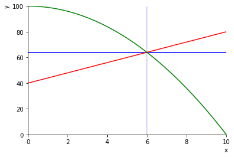

```python
p1=plot_implicit(Eq(x,6),(x, 0, 10), (y, 0, 100),line_color = 'b',show=False)
p2=plot(64, (x, 0, 10), (y, 0, 100),line_color = 'b',show=False)
p3=plot(4*x+40,(x, 0, 10), (y, 0, 100),line_color = 'r' ,show=False)
p4=plot(100-x**2,(x, 0, 10), (y, 0, 100),line_color = 'g' ,show=False)
p1.append(p2[0])
p1.append(p3[0])
p1.append(p4[0])
p1.show()
```

## Ejercicios

1. Halle los excedentes del productor y del consumidor si \begin{align*} D:&\ p= 15-2x \\ O:&\ p= 3+x \end{align*}
2. Halle los excedentes del productor y del consumidor si \begin{align*} D:&\ p= 120-x^2 \\ O:&\ p= 32+3x \end{align*}
3. Halle los excedentes del productor y del consumidor si \begin{align*} O:&\ p= 3.8+0.2x \\ D:&\ p= \frac{370}{x+6} \end{align*}
4. Halle los excedentes del productor y del consumidor si \begin{align*} O:&\ p= 20+2.5x \\ D:&\ p= \frac{280}{x+2} \end{align*}